# Visualizing Twitter Data with a Packed Barchart

Adam Spannbauer

2018-01-28

Before we start the process of getting and visualizing the twitter data. Lets go ahead and take a peak at the packed barchart that will be the output of the process.

[interactive chart not shown]

## Gathering Twitter Data

Before we can visualize any data we’ll have to gather it. There are R twitter packages out there, such as `twitteR`, but I prefer to use a custom function (shown below). If you’d like to use the custom function, you’ll first need to provide your api keys/secrets.

#### Define API Keys

```r
api_key     = 'xxxxxxxxxxxxxxxxxxxxxxxxx'
api_secret  = 'xxxxxxxxxxxxxxxxxxxxxxxxxxxxxxxxxxxxxxxxxxxxxxxxxx'
access_token        = 'xxxxxxxxx-xxxxxxxxxxxxxxxxxxxxxxxxxxxxxxxxxxxxxxxx'
access_token_secret = 'xxxxxxxxxxxxxxxxxxxxxxxxxxxxxxxxxxxxxxxxxxxxx'
```

#### Custom Twitter API Function

```r
#custom function to get tweets by a username
get_user_tweets = function(user, n, api_key, api_secret, access_token, access_token_secret) {
  #set up oauth
  auth = httr::oauth_app("twitter", key=api_key, secret=api_secret)
  sig  = httr::sign_oauth1.0(auth, token=access_token, token_secret=access_token_secret)
  #loop through GETs getting max of 200 per iteration
  nLeft = n
  i = 0
  timeline = vector("list", n)
  while (nLeft > 0) {
    nToGet = min(200, nLeft)
    i = i+1
    #build GET URL
    if (i == 1) {
      GETurl = paste0("https://api.twitter.com/1.1/statuses/user_timeline.json?screen_name=",
                      user,"&count=", nToGet)
    } else {
      GETurl = paste0("https://api.twitter.com/1.1/statuses/user_timeline.json?screen_name=",
                      user,"&count=", nToGet,"&max_id=", max_id)
    }
    #actual GET and content extract
    timelineRaw = httr::GET(GETurl, sig)
    timelineContent = httr::content(timelineRaw)
    #accumulate content
    if (i==1) {
      timeline = timelineContent
    } else {
      timeline = c(timeline, timelineContent)
    }
    max_id = min(vapply(timelineContent, function(ls) ls$id, numeric(1)))

    nLeft = nLeft - nToGet
  }
  return(timeline)
}
```

#### Cleaning the Data

We now have a working function to get our tweet data. In the below chunk we call the function and wrangle the data into a nice `data.table` structure for plotting.

```r
#call custom function to get tweets for a given user
my_tweets = get_user_tweets(user="ASpannbauer", n=1000,
                            api_key, api_secret, access_token, access_token_secret)

#parse out the information we want into a list of data.tables
tweet_dt_list = lapply(my_tweets, function(tweet) {
  data.table::data.table(time  = tweet$created_at,
                         text  = tweet$text,
                         user  = tweet$user$screen_name,
                         fav_n = tweet$favorite_count,
                         rt_n  = tweet$retweet_count)
})
#combine list into single data.table
tweet_dt = data.table::rbindlist(tweet_dt_list)
#remove retweets
tweet_dt = tweet_dt[!grepl("^RT", text), ]

#combine count of favorites and retweets into single count
tweet_dt[,total_fav_rt := fav_n + rt_n]
#truncate tweet text for a preview of the tweet in the viz
tweet_dt[,text_preview := paste0(substr(text, 1, 20), "...")]
#order by descending popularity
tweet_dt = tweet_dt[order(-total_fav_rt), ]
#inspect head of data
head(tweet_dt[, -c("time","text")])
```

```
##           user fav_n rt_n total_fav_rt            text_preview
## 1: ASpannbauer   295   56          351 Most NSFW minute in ...
## 2: ASpannbauer   160   20          180 Analyzing emotes in ...
## 3: ASpannbauer    55   13           68 I transformed my res...
## 4: ASpannbauer    55    5           60 Playing around with ...
## 5: ASpannbauer    18   14           32 Trump Doesnt like Mo...
## 6: ASpannbauer    21    9           30 New festive post on ...
```

## Plotting the Twitter Data

Before plotting with the packed barchart let’s take a peak at the distribution of the metric we’ll be plotting. As we see in the plot below, this data is very skewed. This type of distribution is a good case for the packed barchart’s intended design.

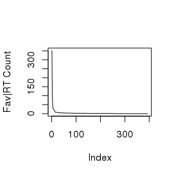

```r
plot(tweet_dt$total_fav_rt, type = 'l', ylab = "Fav|RT Count")
```

At this point, we’re ready to use the packed barchart to see our twitter data in a new light. To do this we call the function `rPackedBar::plotly_packed_bar` and specify our options.

- `input_data` - the name of the `data.frame` type object containing the data to plot
- `label_column` - the column in the `input_data` contining labels for our plotted numeric data
- `value_column` - the column in the `input_data` contining the numeric data to plot
- `number_rows` - the number of rows our packed barchart will contain
- `plot_title` - the main title to display over the chart
- `xaxis_label` - the title to display for the xaxis
- `hover_label` - title to appear in the hover information
- `min_label_width` - parameter to prevent text labels spilling over the bounds of the bars
- `color_bar_color` - color of the largest colored bars in the chart
- `label_color` - color of the labels to appear over the colored bars in the chart

```r
p = rPackedBar::plotly_packed_bar(input_data = tweet_dt[total_fav_rt > 0, ],
                                  label_column = "text_preview",
                                  value_column = "total_fav_rt",
                                  number_rows = 4,
                                  plot_title = "Tweet Interactions",
                                  xaxis_label = "Favorites & RTs",
                                  hover_label = "Favs & RTs",
                                  min_label_width = .1,
                                  color_bar_color = "#00aced",
                                  label_color = "white")
plotly::config(p, displayModeBar = FALSE)
```

[interactive chart not shown]